# Introduction to R and R Objects

Prepared for Brierley+Partner’s Consumer Insights Team by Graham Landry

April 3rd, 2017

# This Week’s Training Schedule

The trainings this week will introduce you to the R language as well as demonstrate common tasks during data analysis. We will begin today with an overview of the R language before moving on to importing/writing files, data manipulation, data visualization, modeling, and an introduction to R programming.

Whether the information we cover today is brand new or review, it’s a good place to start as it forms the requisite knowledge for the concepts presented on Day 2 and Day 3- not to mention anything else you might want to explore with your knew skills in R.

**The ultimate goal of these trainings is to provide you with a solid foundation upon which you can continue to explore the language and further develop your skillset.**

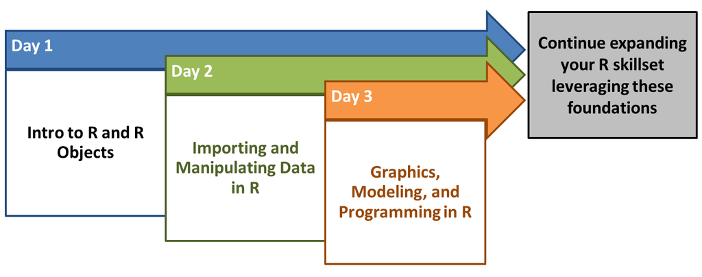

# Topics for Today’s Training

- Introduction to the R Language
- Importance of Understanding R Objects
- Object Assignment
- Operators
- The Recycling Rule
- Operating with Boolean Values
- Generating Numbers
- R Data Types
- Special Values in R
- R Data Structures
- Object Attributes
- Testing and Coercing Objects
- Subsetting and Indexing Objects
- The Working Directory and R Environments
- Getting Help with R
- Additional Resources

# Introduction to the R Language

As written in the beginning pages of *An Introduction to R* by Venables, Smith, and the R Core Team:

*R is an integrated suite of software facilities for data manipulation, calculation, and graphical display. Among other things it has:*

- *an effective data handling and storage facility*
- *a suite of operators for **calculations on arrays**, in particular matrices*
- *a large, coherent, integrated collection of **tools for data analysis***
- **graphical facilities** for data analysis and display, and
- *a well developed, **simple and effective programming language** which includes conditionals, loops, user-defined recursive functions and input/output facilities*

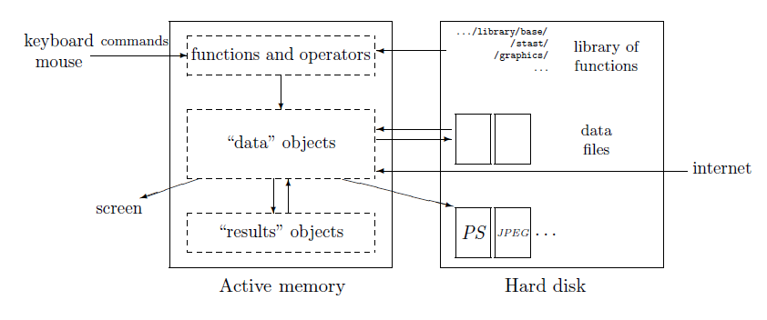

*Figure 1.1: How R Works*

*Source: R for Beginners (pg. 4)*

# Introduction to the R Language

About the language:

- R is a multi-paradigm language with implementations of object-oriented, procedural, and functional programming paradigms (among others)
- It is open source!! [Comprehensive R Archive Network (CRAN)](https://cran.r-project.org/)
- The R language as its known today is based upon the **S** language first developed at Bell Labs by John Chambers
- There is a vast collection of **packages** available for download. Packages are a collection of reusable R functions typically focused on a certain task or topic (i.e. data wrangling, graphics, machine learning, time-series analysis, etc.)

As a user:

- R stores all data in active memory, so don’t overload it!
- R is **case sensitive**
- Commands can be separated either by a new line or ;
- Commenting in R is done with the # symbol

# Importance of Understanding R Objects

Having a good understanding of R data types and data structures is important because:

1. It will help you anticipate the output generated from various functions or algorithms
2. It will help you better understand error and warning messages when they occur
3. It will greatly increase the velocity with which you learn the language

For example there are over 200 different **print()** methods, and as you might expect this function can yield different output depending on the object passed into it. Without an understanding of which objects a function operates on, or how a function may behave differently depending on the object, your time spent debugging code and searching for answers online will increase dramatically.

```r
methods(print)
```

# Object Assignment

To assign an object a value in your environment, you use the **<-** operator which *points* towards the object receiving the value.

Generally, you have freedom in choosing the name for an object but there are a few rules:

- Object names can contain only letters, numbers, and the characters . and _
- All object names must start with a letter, or . not followed by a number
- Be sure to avoid reserved words (see ?Reserved)
- As best as possible, give contextualized names to objects

After creating a variable (or any other object), you can remove it from your environment using the **rm()** command.

```r
# common assignment pattern, pay attention to what happens in your Environment pane
greet <- "Hello, world!"

# this assignment pattern is less common, but it still works
"Hello, world...again!" -> greet2

print(c(greet, greet2))

# you can remove a variable from your environment using rm()
rm(greet, greet2)
```

# Try it!: Object Assignment

```r
# assign objects raw values...
x <- 2
y <- 13

# or assign objects a value using operations on other objects
z <- y - x

print(c(x, y, z))

# what would you expect the value of x to be now? what about z?
x <- x + 5

print(c(x, z))

# you can remove all objects in environment by supplying list=ls() to rm()
rm(list=ls())
```

# Operators

The R language includes a full inventory of operators commonly used in data analysis. Here is a nice summary table taken from *R for Beginners* (pg. 25). Notice that the equality operator in R is **==** (as opposed to *=* as in other languages).

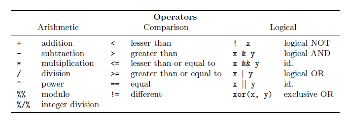

*Figure 1.2: Categorized R Operators*

*Source: R for Beginners (pg. 25)*

R’s operators are **vectorized**: adding two vectors of the same length results in a vector with the same length and containing the element-wise sum.

```r
# this is possible
20 + 33

#  but this is not possible
"Hello," + "world!"

# operators are vectorized
x <- c(1, 2, 3)
y <- c(4, 5, 6)

x + y

# you can also remove objects from the environment using remove()
remove(x, y)
```